# Coursework

## Assessment – Data Classification (60 marks)

The programming language you should use to finish this assessment is Python (in version 3 and above). You can use functions from the following packages: Numpy, Pandas, Matplotlib, Seaborn and Sklearn. All Python skills needed to do this assessment have been covered in the practical sessions –practical notes are available on Canvas.

### Information on the Data

The dataset that you will be using for this coursework is the Banknote Dataset.

The Banknote Dataset involves predicting whether a given banknote is authentic given a number of measures taken from a photograph.

It is a binary (2-class) classification problem. The number of observations for each class is not balanced. There are 1,372 observations with 4 input variables and 1 output variable. The variable names are as follows:

- Variance of Wavelet Transformed image (continuous).
- Skewness of Wavelet Transformed image (continuous).
- Kurtosis of Wavelet Transformed image (continuous).
- Entropy of image (continuous).
- Class (0 for authentic, 1 for inauthentic).

```python
import pandas as pd
import numpy as np
import matplotlib.pyplot as plt
import collections
import seaborn as sns
import matplotlib
```

### Task 1: Data pre-processing and data exploration (12 marks)

#### a) Load and display the dataset bank_notes.csv (2 mark).

```python
# File path
file_path = r"C:\Users\kamalFD\OneDrive\Desktop\Jupyter dsatasets\bank_notes.csv"
# Load dataset
df = pd.read_csv(file_path)
# Display the first 10 rows
print(df.head(10).to_string())
```

```
   variance  skewness  curtosis  entropy  Target
0   3.62160    8.6661  -2.80730 -0.44699       0
1   4.54590    8.1674  -2.45860 -1.46210       0
2   3.86600   -2.6383   1.92420  0.10645       0
3   3.45660    9.5228  -4.01120 -3.59440       0
4   0.32924   -4.4552   4.57180 -0.98880       0
5   4.36840    9.6718  -3.96060 -3.16250       0
6   3.59120    3.0129   0.72888  0.56421       0
7   2.09220   -6.8100   8.46360 -0.60216       0
8   3.20320    5.7588  -0.75345 -0.61251       0
9   1.53560    9.1772  -2.27180 -0.73535       0
```

### Load and display the dataset

1)The Banknotes.csv dataset was saved under the file_path of "C:\Users\kamalFD\OneDrive\Desktop\Jupyter dsatasets\bank_notes.csv" where the file was originally saved.

#### b) Investigate the bank_notes dataset by using appropriate commands, explain your findings in a markdown cell (2 marks).

```
First 5 rows:
   variance  skewness  curtosis  entropy  Target
0   3.62160    8.6661   -2.8073 -0.44699       0
1   4.54590    8.1674   -2.4586 -1.46210       0
2   3.86600   -2.6383    1.9242  0.10645       0
3   3.45660    9.5228   -4.0112 -3.59440       0
4   0.32924   -4.4552    4.5718 -0.98880       0

Shape: (1372, 5)

Data types:
variance    float64
skewness    float64
curtosis    float64
entropy     float64
Target        int64
dtype: object

Missing values:
variance    0
skewness    0
curtosis    0
entropy     0
Target      0
dtype: int64

Duplicate rows: 24

Class distribution:
Target
0    762
1    610
Name: count, dtype: int64

Class distribution %:
Target
0    55.54
1    44.46
Name: proportion, dtype: float64

Majority: 762 Minority: 610
Imbalance ratio: 1.25
Interpretation: Dataset is fairly balanced.
```

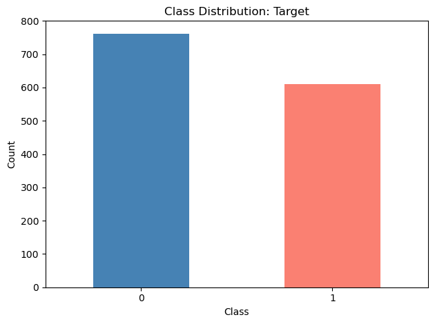

```
Unique values per column:
variance    1338
skewness    1256
curtosis    1270
entropy     1156
Target         2
dtype: int64

Correlation matrix:
          variance  skewness  curtosis  entropy  Target
variance      1.00      0.26     -0.38     0.28   -0.72
skewness      0.26      1.00     -0.79    -0.53   -0.44
curtosis     -0.38     -0.79      1.00     0.32    0.16
entropy       0.28     -0.53      0.32     1.00   -0.02
Target       -0.72     -0.44      0.16    -0.02    1.00

Final dataset shape: (1372, 5)
X shape: (1372, 4)
y shape: (1372,)
Preprocessing complete.
```

```python
# Step 1: Dataset Info
print("First 5 rows:")
print(df.head())
print("\nShape:", df.shape)
print("\nData types:")
print(df.dtypes)
print("\nMissing values:")
print(df.isnull().sum())
print("\nDuplicate rows:", df.duplicated().sum())

# Step 2: Class Distribution
class_counts  = df[target_col].value_counts()
class_percent = df[target_col].value_counts(normalize=True) * 100
print("\nClass distribution:")
print(class_counts)
print("\nClass distribution %:")
print(class_percent.round(2))

# Step 3: Balance Check
majority = class_counts.max()
minority = class_counts.min()
imbalance_ratio = majority / minority
print("\nMajority:", majority, "Minority:", minority)
print(f"Imbalance ratio: {imbalance_ratio:.2f}")
if imbalance_ratio <= 1.5:
    print("Interpretation: Dataset is fairly balanced.")
elif imbalance_ratio <= 3:
    print("Interpretation: Dataset is moderately imbalanced.")
else:
    print("Interpretation: Dataset is highly imbalanced.")

# Step 4: Class Distribution Chart
class_counts.plot(kind="bar", color=["steelblue", "salmon"])
plt.title(f"Class Distribution: {target_col}")
plt.xlabel("Class")
plt.ylabel("Count")
plt.xticks(rotation=0)
plt.tight_layout()
plt.show()

# Step 5: Unique Values and Correlation Matrix
print("\nUnique values per column:")
print(df.nunique())
print("\nCorrelation matrix:")
print(df.corr(numeric_only=True).round(2))

# Step 6: Build X and y
X = df.drop(columns=[target_col])
y = df[target_col]
print("\nFinal dataset shape:", df.shape)
print("X shape:", X.shape)
print("y shape:", y.shape)
print("Preprocessing complete.")
```

### Pre-processing Data Mining

To process an efficient & reliable classification model, the dataset required thorough inspection to determine whether any duplicate data, missing values, outliers and inconsistencies were present in the dataset that could potentially undermine the overall performance of the model. A further inspection of the class imbalance will be carried out to review, analyse and determine the class distribution spread, as well as identifying the appropiate imbalance method to be applied, if required in the data splitting section.

#### To address this matter the following codes were applied:

##### 2. Class distribution.

The class distribution illustrates the spread of class labels within the dataset, expressed in both raw counts and percentage. The dataset contains 762 instances labelled as class "0" and 610 instances labelled as class "1", representing 55.54% and 44.46% of the total datase. This provides an indication of whether the dataset is balanced or imbalanced prior to model building.

##### 3. Balance check.

As mentioned in the assignment instruction, the dataset contains an imbalanced class distribution. The balance check evaluates the class distribution by computing the imbalance ratio, which resulted in 1.25, indicating a fairly balanced dataset. This approach is crucial for the choice of balancing method for subsequent model training.

##### 4. Class distribution chart

Class distribution chart provides a visual overview of the number of instances belonging to each class label, illustrating the sample size of each class.

##### 5. Unique values and correlation.

Unique values measures column variety by counting how many unique data points are present within each feature. The correlation matrix quantifies the degree to which two features influence one another, with values ranging from -1 (strong negative relationship) to +1 (strong positive relationship).

##### 6. Final Dataset Shape.

The final dataset summary reveals no missing values present in the dataset, however duplicates and outliers were present, which will be addressed in the data splitting section.

### c) Show a scatter plot of your own choice, that is, one feature against another feature. You need to use the training set. Explain your code in a markdown cell (4 marks).

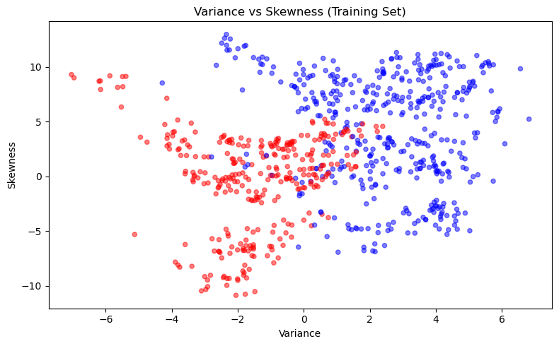

```python
# Step 14: Scatter Plot - Variance vs Skewness (Training Set)
plt.figure(figsize=(8, 5))

plt.scatter(X_train["variance"], X_train["skewness"], c=y_train, cmap="bwr", alpha=0.5, s=20)

plt.title("Variance vs Skewness (Training Set)")
plt.xlabel("Variance")
plt.ylabel("Skewness")
plt.tight_layout()
plt.show()
```

#### d) Divide the dataset into a training set (60%), a validation set (20%) and a test set (20%). Explain the code in a markdown cell (4 marks).

```python
from sklearn.model_selection import train_test_split

# Step 10: Split into Training (60%), Validation (20%), Test (20%)

# First split: 60% train, 40% temp
X_train, X_temp, y_train, y_temp = train_test_split(
    X, y, test_size=0.40, random_state=42, stratify=y
)

# Second split: split the 40% temp into 50/50 -> 20% val, 20% test
X_val, X_test, y_val, y_test = train_test_split(
    X_temp, y_temp, test_size=0.50, random_state=42, stratify=y_temp
)

print("Dataset split summary:")
print(f"  Training   set: {X_train.shape[0]} rows ({X_train.shape[0]/len(X)*100:.1f}%)")
print(f"  Validation set: {X_val.shape[0]} rows ({X_val.shape[0]/len(X)*100:.1f}%)")
print(f"  Test       set: {X_test.shape[0]} rows ({X_test.shape[0]/len(X)*100:.1f}%)")

# Step 11: Remove Duplicates from Training Set Only
train_df = pd.concat([X_train, y_train], axis=1)
print("\nShape before duplicate removal:", train_df.shape)
train_df = train_df.drop_duplicates().reset_index(drop=True)
print("Shape after duplicate removal:", train_df.shape)
print("Remaining duplicates:", train_df.duplicated().sum())

X_train = train_df.drop(columns=[target_col])
y_train = train_df[target_col]

# Step 12: Outlier Removal from Training Set Only (IQR Method)
numeric_cols = X_train.columns

print("\nOutliers detected per column (training set):")
for col in numeric_cols:
    Q1  = X_train[col].quantile(0.25)
    Q3  = X_train[col].quantile(0.75)
    IQR = Q3 - Q1
    outlier_count = ((X_train[col] < Q1 - 1.5 * IQR) | (X_train[col] > Q3 + 1.5 * IQR)).sum()
    print(f"  {col}: {outlier_count}")

# Combine X_train and y_train to remove outlier rows together
train_df = pd.concat([X_train, y_train], axis=1)
print("\nShape before outlier removal:", train_df.shape)

for col in numeric_cols:
    Q1  = X_train[col].quantile(0.25)
    Q3  = X_train[col].quantile(0.75)
    IQR = Q3 - Q1
    train_df = train_df[
        (train_df[col] >= Q1 - 1.5 * IQR) &
        (train_df[col] <= Q3 + 1.5 * IQR)
    ]

train_df = train_df.reset_index(drop=True)
print("Shape after outlier removal:", train_df.shape)

X_train = train_df.drop(columns=[target_col])
y_train = train_df[target_col]

# Step 13: Class Distribution Check (post-split)
print("\nClass distribution in training set:")
print(y_train.value_counts())
print(f"Imbalance ratio: {y_train.value_counts().max() / y_train.value_counts().min():.2f}")
```

```
Dataset split summary:
  Training   set: 823 rows (60.0%)
  Validation set: 274 rows (20.0%)
  Test       set: 275 rows (20.0%)

Shape before duplicate removal: (823, 5)
Shape after duplicate removal: (813, 5)
Remaining duplicates: 0

Outliers detected per column (training set):
  variance: 0
  skewness: 0
  curtosis: 41
  entropy: 17

Shape before outlier removal: (813, 5)
Shape after outlier removal: (755, 5)

Class distribution in training set:
Target
0    437
1    318
Name: count, dtype: int64
Imbalance ratio: 1.37
```

### The dataset was divided into 3 splits of 60% training - 20% validation - 20% test applying the following;

#### 1.

The dataset was split into 60% training split that also included removing duplicates and outliers from the training set.

#### 2.

The dataset was further split into 20% validation and 20% test split, while duplicates and outliers remain untouched with the purpose of unbiased evaluation.

#### 3.

The print function ensure the code applied were successfully executed resulting in:

### Task 2: Do a principal component analysis (18 marks)

#### a) Normalise the TOTAL training dataset (a dataset that include the training and validation dateset) and perform a PCA analysis on the TOTAL training data set.Explain your code in a markdown cell. (6 marks).

```
Total training set shape: (1029, 4)

Standardisation Summary:
  Mean per feature:
  [-0. -0.  0.  0.]
  Std  per feature:
  [1. 1. 1. 1.]

Covariance Matrix:
          variance  skewness  curtosis  entropy
variance    1.0010    0.2347   -0.3147   0.2011
skewness    0.2347    1.0010   -0.7411  -0.5974
curtosis   -0.3147   -0.7411    1.0010   0.4378
entropy     0.2011   -0.5974    0.4378   1.0010
```

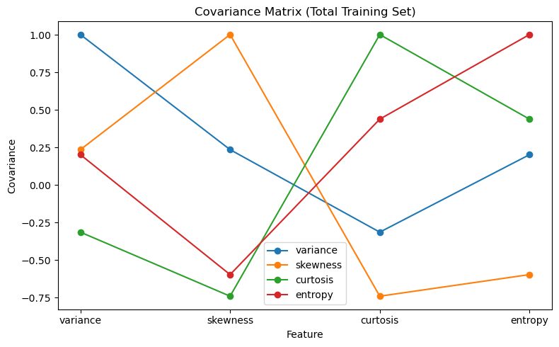

```
Eigenvalues:
  PC1: 0.2232
  PC2: 0.3554
  PC3: 1.1881
  PC4: 2.2371

Eigenvectors (each column is a principal component):
               0       1       2       3
variance  0.1298 -0.5010  0.8342 -0.1905
skewness -0.7829  0.0301 -0.0020 -0.6214
curtosis -0.4920 -0.6192 -0.1605  0.5905
entropy  -0.3579  0.6039  0.5276  0.4784
```

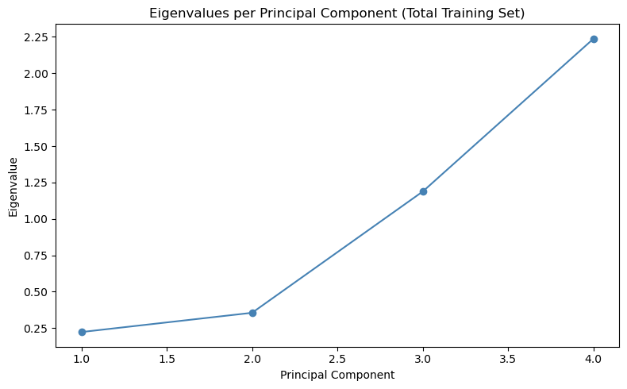

```
Explained variance ratio per component:
  PC1: 55.87%
  PC2: 29.67%
  PC3: 8.88%
  PC4: 5.58%

Cumulative explained variance:
  PC1 to PC1: 55.87%
  PC1 to PC2: 85.55%
  PC1 to PC3: 94.42%
  PC1 to PC4: 100.00%
```

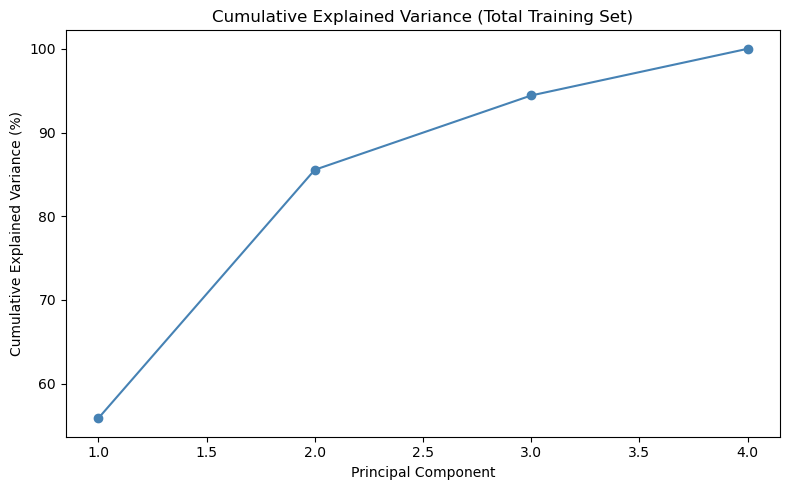

```python
from sklearn.preprocessing import StandardScaler
from sklearn.decomposition import PCA

# Step 15: Combine Training and Validation sets into TOTAL training set
X_total = pd.concat([pd.DataFrame(X_train, columns=X.columns), X_val], ignore_index=True)
y_total = pd.concat([pd.Series(y_train), y_val], ignore_index=True)
print("Total training set shape:", X_total.shape)

# Step 16: Normalise the TOTAL training set
scaler = StandardScaler()
X_total_scaled = scaler.fit_transform(X_total)
print("\nStandardisation Summary:")
print(f"  Mean per feature:\n  {X_total_scaled.mean(axis=0).round(4)}")
print(f"  Std  per feature:\n  {X_total_scaled.std(axis=0).round(4)}")

# Step 17: Covariance Matrix
cov_matrix = np.cov(X_total_scaled.T)
print("\nCovariance Matrix:")
print(pd.DataFrame(cov_matrix, columns=X.columns, index=X.columns).round(4))
plt.figure(figsize=(8, 5))
for i, col in enumerate(X.columns):
    plt.plot(X.columns, cov_matrix[i], marker="o", label=col)
plt.title("Covariance Matrix (Total Training Set)")
plt.xlabel("Feature")
plt.ylabel("Covariance")
plt.legend()
plt.tight_layout()
plt.show()

# Step 18: Eigenvalues and Eigenvectors
eigenvalues, eigenvectors = np.linalg.eigh(cov_matrix)
print("\nEigenvalues:")
for i, val in enumerate(eigenvalues):
    print(f"  PC{i+1}: {val:.4f}")
print("\nEigenvectors (each column is a principal component):")
print(pd.DataFrame(eigenvectors, index=X.columns).round(4))
plt.figure(figsize=(8, 5))
plt.plot(range(1, len(eigenvalues) + 1), eigenvalues,
         color="steelblue", marker="o")
plt.title("Eigenvalues per Principal Component (Total Training Set)")
plt.xlabel("Principal Component")
plt.ylabel("Eigenvalue")
plt.tight_layout()
plt.show()

# Step 19: PCA on the TOTAL training set (all components)
pca = PCA()
X_total_pca = pca.fit_transform(X_total_scaled)
print("\nExplained variance ratio per component:")
for i, var in enumerate(pca.explained_variance_ratio_):
    print(f"  PC{i+1}: {var*100:.2f}%")
print("\nCumulative explained variance:")
cumulative = 0
for i, var in enumerate(pca.explained_variance_ratio_):
    cumulative += var * 100
    print(f"  PC1 to PC{i+1}: {cumulative:.2f}%")
plt.figure(figsize=(8, 5))
plt.plot(range(1, len(pca.explained_variance_ratio_) + 1),
         pca.explained_variance_ratio_.cumsum() * 100,
         color="steelblue", marker="o")
plt.title("Cumulative Explained Variance (Total Training Set)")
plt.xlabel("Principal Component")
plt.ylabel("Cumulative Explained Variance (%)")
plt.tight_layout()
plt.show()
```

##### 1 — Combine Training and Validation Sets

The training and validation sets were recombined into a single training set, with the aim of maximising the data available for PCA & final model evaluation upon completion of parameter tuning.

##### 2 — Standardisation

The total training set was normalised to "0" representing the mean and standard deviation of "1", ensuring that PCA is not bias due to differences in numerical ranges.

##### 3 — Covariance Matrix

A covariance matrix was computed from the standardised data to quantify the linear relationships between features, providing the fundamentaæ backbone for identifying principal components.

##### 4 — Eigenvalues and Eigenvectors

Eigendecomposition was applied to the covariance matrix to extract eigenvalues and eigenvectors, where eigenvalues indicate the variance captured by each principal component and eigenvectors define their directions in feature space.

##### 5 — PCA and Explained Variance

PCA was applied to the normalised total training set and the explained variance ratio per component was computed, with the cumulative plot used to determine how many components were required to maintain a sufficient proportion of the dataset's variance.

#### b) Plot a scree plot to report variances captured by each principal component (4 marks).

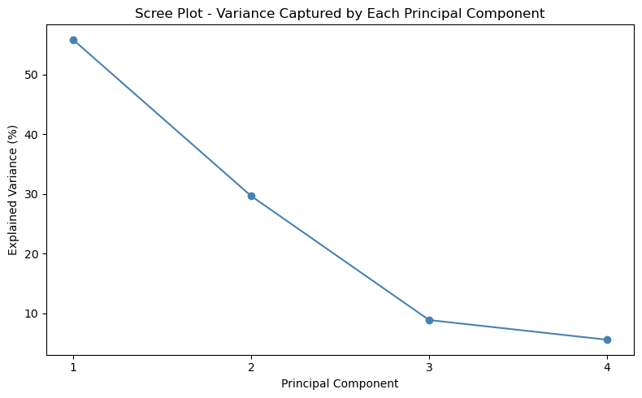

```
Variance captured by each component:
  PC1: 55.87%
  PC2: 29.67%
  PC3: 8.88%
  PC4: 5.58%
```

```python
# Scree Plot - Variance captured by each Principal Component
plt.figure(figsize=(8, 5))
plt.plot(range(1, len(pca.explained_variance_ratio_) + 1),
         pca.explained_variance_ratio_ * 100,
         color="steelblue", marker="o")
plt.title("Scree Plot - Variance Captured by Each Principal Component")
plt.xlabel("Principal Component")
plt.ylabel("Explained Variance (%)")
plt.xticks(range(1, len(pca.explained_variance_ratio_) + 1))
plt.tight_layout()
plt.show()

print("\nVariance captured by each component:")
for i, var in enumerate(pca.explained_variance_ratio_):
    print(f"  PC{i+1}: {var*100:.2f}%")
```

#### c) Project the test set on the same PCA space produced by the TOTAL training dataset (2 marks).

```
Test set projected onto PCA space.
Original test set shape : (275, 4)
PCA projected shape     : (275, 4)

First 5 rows of the projected test set:
      PC1     PC2     PC3     PC4
0  0.5951  1.3642 -0.2750  0.5626
1 -0.9890  0.4121  0.6601  0.2604
2 -1.6789 -0.4130  0.0260  1.2379
3 -0.3382  1.5036  0.0835  0.3186
4  0.6836 -1.8382 -0.2826 -0.3122
```

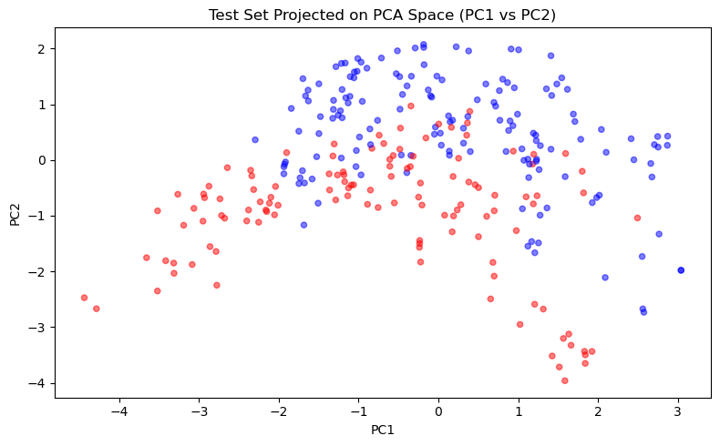

```python
# Project the Test Set onto the PCA space of the Total Training Set

# Step 1: Normalise the test set using the SAME scaler fitted on the total training set
X_test_scaled = scaler.transform(X_test)

# Step 2: Project the test set onto the same PCA space
X_test_pca = pca.transform(X_test_scaled)

print("Test set projected onto PCA space.")
print(f"Original test set shape : {X_test.shape}")
print(f"PCA projected shape     : {X_test_pca.shape}")

# Step 3: Print the first 5 projected rows
print("\nFirst 5 rows of the projected test set:")
print(pd.DataFrame(X_test_pca, columns=[f"PC{i+1}" for i in range(X_test_pca.shape[1])]).head().round(4))

# Step 4: Scatter plot of test set in PCA space (PC1 vs PC2)
plt.figure(figsize=(8, 5))
plt.scatter(X_test_pca[:, 0], X_test_pca[:, 1], c=y_test, cmap="bwr", alpha=0.5, s=20)
plt.title("Test Set Projected on PCA Space (PC1 vs PC2)")
plt.xlabel("PC1")
plt.ylabel("PC2")
plt.tight_layout()
plt.show()
```

#### d) Plot two subplots in one figure: one for the TOTAL training data in the PC1 and PC2 projection space and label the data in the picture according to its class; the other one for the test data in the same PCA space and label the data in the picture according to its class. Explain your code in a markdown cell. (6 marks)

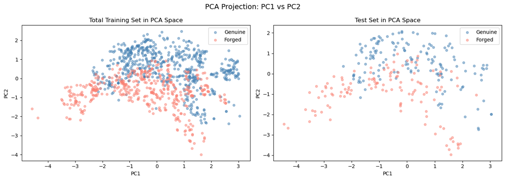

```python
# Plot Total Training and Test Set in PCA Space (PC1 vs PC2)
fig, axes = plt.subplots(1, 2, figsize=(14, 5))

# Subplot 1: Total Training Set
for label, color, name in zip([0, 1], ["steelblue", "salmon"], ["Genuine", "Forged"]):
    mask = y_total.values == label
    axes[0].scatter(X_total_pca[mask, 0], X_total_pca[mask, 1],
                    color=color, label=name, alpha=0.5, s=20)
axes[0].set_title("Total Training Set in PCA Space")
axes[0].set_xlabel("PC1")
axes[0].set_ylabel("PC2")
axes[0].legend()

# Subplot 2: Test Set
for label, color, name in zip([0, 1], ["steelblue", "salmon"], ["Genuine", "Forged"]):
    mask = y_test.values == label
    axes[1].scatter(X_test_pca[mask, 0], X_test_pca[mask, 1],
                    color=color, label=name, alpha=0.5, s=20)
axes[1].set_title("Test Set in PCA Space")
axes[1].set_xlabel("PC1")
axes[1].set_ylabel("PC2")
axes[1].legend()

plt.suptitle("PCA Projection: PC1 vs PC2", fontsize=14)
plt.tight_layout()
plt.show()
```

## PCA Projection - Total Training Set vs Test Set

Two subplots were aligned side by side to compare how the total training set and the test set look in the PCA projected space defined by PC1 and PC2.

Each data point is defined by its coloured class — blue representing genuine bank notes and red representing forged bank notes. This approach enables a visual evaluation of how well PC1 and PC2 separate the two classes.

### Task 3: Train a classification model using the Naïve Bayes Classification algorithm. Explain your code in a markdown cell. (8 marks)

Train the model using the TOTAL training set and report the performance on the test set including accuracy rate.

```python
from sklearn.naive_bayes import GaussianNB
from sklearn.metrics import accuracy_score, classification_report, confusion_matrix

# Train Naive Bayes on the PCA-projected total training set
nb_model = GaussianNB()
nb_model.fit(X_total_pca, y_total)

# Predict on the test set
y_pred = nb_model.predict(X_test_pca)

# Results
print("Naive Bayes Classification Results")
print("\nAccuracy:", round(accuracy_score(y_test, y_pred), 4))
print("\nClassification Report:")
print(classification_report(y_test, y_pred, target_names=["Genuine", "Forged"]))
print("Confusion Matrix:")
print(confusion_matrix(y_test, y_pred))
```

```
Naive Bayes Classification Results

Accuracy: 0.9636

Classification Report:
              precision    recall  f1-score   support

     Genuine       1.00      0.93      0.97       153
      Forged       0.92      1.00      0.96       122

    accuracy                           0.96       275
   macro avg       0.96      0.97      0.96       275
weighted avg       0.97      0.96      0.96       275

Confusion Matrix:
[[143  10]
 [  0 122]]
```

## Naive Bayes Classification

Naive Bayes model were trained on the PCA-projected total training set. The model was trained & evaluated on `X_total_pca` and `y_total` which is the total training set (training + validation) projected onto the PCA space. We then predict `X_test_pca` which is the test set projected onto the same PCA space.

### Task 4: Investigate how the number of features in the training dataset affects the model performance on the validation set. (16 marks)

#### a) Use the training set to train 4 Naïve Bayes Classification models, with 4 different feature sets. That is: the first one is to use the 1st feature only; the second one is to use the 1st and the 2nd features; the third one is to use the 1st, 2nd, and 3rd features, the fourth one is to use the first 4 features.Measure the accuracy rate on both the training set and the validation set. Report the results by plotting them in a figure: that is, a plot of the accuracy rate against the number of features used in each model. There should be two curves in this figure: one for the training set; the other one for the validation set. Explain your code in a markdown cell. (10 marks).

```
Model 1 - Features used: ['1. variance']
  Training   accuracy: 0.8477
  Validation accuracy: 0.8467

Model 2 - Features used: ['1. variance', '2. skewness']
  Training   accuracy: 0.8967
  Validation accuracy: 0.8796

Model 3 - Features used: ['1. variance', '2. skewness', '3. curtosis']
  Training   accuracy: 0.8848
  Validation accuracy: 0.8832

Model 4 - Features used: ['1. variance', '2. skewness', '3. curtosis', '4. entropy']
  Training   accuracy: 0.8848
  Validation accuracy: 0.8832
```

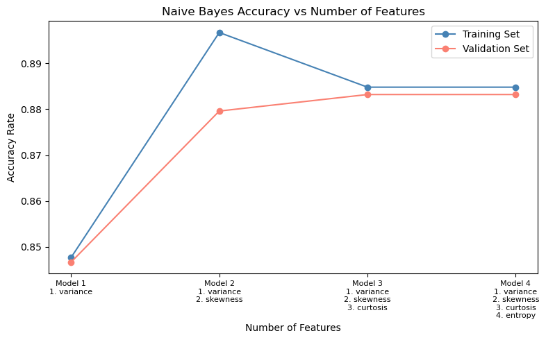

```python
from sklearn.naive_bayes import GaussianNB
from sklearn.metrics import accuracy_score

# Features to use (original features, not PCA)
features = list(X.columns)[:4]  # first 4 features
train_accuracies = []
val_accuracies   = []

# Train 4 models with increasing number of features
for n in range(1, 5):
    selected_features = features[:n]

    # Subset training and validation sets
    X_train_sub = pd.DataFrame(X_train, columns=X.columns)[selected_features]
    X_val_sub   = X_val[selected_features]

    # Train Naive Bayes
    nb = GaussianNB()
    nb.fit(X_train_sub, y_train)

    # Accuracy on training set
    train_acc = accuracy_score(y_train, nb.predict(X_train_sub))
    train_accuracies.append(round(train_acc, 4))

    # Accuracy on validation set
    val_acc = accuracy_score(y_val, nb.predict(X_val_sub))
    val_accuracies.append(round(val_acc, 4))

    print(f"Model {n} - Features used: {[f'{i+1}. {f}' for i, f in enumerate(selected_features)]}")
    print(f"  Training   accuracy: {train_acc:.4f}")
    print(f"  Validation accuracy: {val_acc:.4f}\n")

# Plot training vs validation accuracy
plt.figure(figsize=(8, 5))
plt.plot(range(1, 5), train_accuracies, color="steelblue", marker="o", label="Training Set")
plt.plot(range(1, 5), val_accuracies,   color="salmon",    marker="o", label="Validation Set")

plt.title("Naive Bayes Accuracy vs Number of Features")
plt.xlabel("Number of Features")
plt.ylabel("Accuracy Rate")
plt.xticks(
    range(1, 5),
    [f"Model {n}\n" + "\n".join([f"{i+1}. {f}" for i, f in enumerate(features[:n])]) for n in range(1, 5)],
    fontsize=8
)
plt.legend()
plt.tight_layout()
plt.show()
```

## Effect of Number of Features on Naive Bayes Model Performance

Four Naive Bayes models was implemented on the training set, each using a different number of features:

- Model 1: variance only
- Model 2: variance and skewness
- Model 3: variance, skewness and curtosis
- Model 4: variance, skewness, curtosis and entropy

For each model the accuracy was measured on both the training set and the validation set". The results were plotted as two linear curves in one graph — one for the training set and one for the validation set — with the purpose of assessing how performance changes as more features are added to the model.

The x-axis labels illustrates the model number and list the features used in numerical order, whereas the "y-axis" was utilised to measure the accuracy of each model, making it easy to see exactly which features each model includes, as well as the accuracy.

#### b) Explain how you choose the best number of features for this task, and state what that best number of features is. Explain your findings in a markdown cell. (3 marks).

#### c) Use the selected number of features to train the model and report the performance on the test set (3 marks).

```
Model 1 - Features used: ['1. variance']
  Training   accuracy: 0.8477
  Validation accuracy: 0.8467

Model 2 - Features used: ['1. variance', '2. skewness']
  Training   accuracy: 0.8967
  Validation accuracy: 0.8796

Model 3 - Features used: ['1. variance', '2. skewness', '3. curtosis']
  Training   accuracy: 0.8848
  Validation accuracy: 0.8832

Model 4 - Features used: ['1. variance', '2. skewness', '3. curtosis', '4. entropy']
  Training   accuracy: 0.8848
  Validation accuracy: 0.8832
```

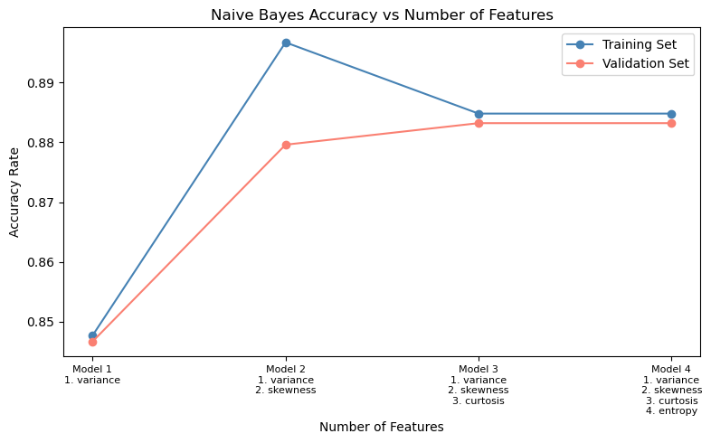

[output not shown]

```python
from sklearn.naive_bayes import GaussianNB
from sklearn.metrics import accuracy_score, classification_report, confusion_matrix

# Features to use (original features, not PCA)
features = list(X.columns)[:4]  # first 4 features
train_accuracies = []
val_accuracies   = []

# Train 4 models with increasing number of features
for n in range(1, 5):
    selected_features = features[:n]

    # Subset training and validation sets
    X_train_sub = pd.DataFrame(X_train, columns=X.columns)[selected_features]
    X_val_sub   = X_val[selected_features]

    # Train Naive Bayes
    nb = GaussianNB()
    nb.fit(X_train_sub, y_train)

    # Accuracy on training set
    train_acc = accuracy_score(y_train, nb.predict(X_train_sub))
    train_accuracies.append(round(train_acc, 4))

    # Accuracy on validation set
    val_acc = accuracy_score(y_val, nb.predict(X_val_sub))
    val_accuracies.append(round(val_acc, 4))

    print(f"Model {n} - Features used: {[f'{i+1}. {f}' for i, f in enumerate(selected_features)]}")
    print(f"  Training   accuracy: {train_acc:.4f}")
    print(f"  Validation accuracy: {val_acc:.4f}\n")

# Plot training vs validation accuracy
plt.figure(figsize=(8, 5))
plt.plot(range(1, 5), train_accuracies, color="steelblue", marker="o", label="Training Set")
plt.plot(range(1, 5), val_accuracies,   color="salmon",    marker="o", label="Validation Set")
plt.title("Naive Bayes Accuracy vs Number of Features")
plt.xlabel("Number of Features")
plt.ylabel("Accuracy Rate")
plt.xticks(
    range(1, 5),
    [f"Model {n}\n" + "\n".join([f"{i+1}. {f}" for i, f in enumerate(features[:n])]) for n in range(1, 5)],
    fontsize=8
)
plt.legend()
plt.tight_layout()
plt.show()


# Final Model - Train on best 2 features (variance and skewness) and report on test set
best_features = ["variance", "skewness"]

X_train_best = pd.DataFrame(X_train, columns=X.columns)[best_features]
X_test_best  = X_test[best_features]

nb_best = GaussianNB()
nb_best.fit(X_train_best, y_train)

y_pred_test = nb_best.predict(X_test_best)

print("Final Model - Best 2 Features (variance and skewness)")
print("\nTest Set Accuracy:", round(accuracy_score(y_test, y_pred_test), 4))
print("\nClassification Report:")
print(classification_report(y_test, y_pred_test, target_names=["Genuine", "Forged"]))
print("Confusion Matrix:")
print(confusion_matrix(y_test, y_pred_test))
```